# Danish Kings

Jakob Tinmahan, Kresten Clausen, Smilla Larsen

2025-3-5

## Load the kings

1. Look at the dataset that are you loading and check what its columns are separated by?

List what is the separator: ##Comma (csv)

2. Create a `kings` object in R with the different functions below and inspect the different outputs.

```r
library(tidyverse)
library(tidyverse)
konger1 <- read.csv ("data/konge.csv")

konger2 <- read_csv("data/konge.csv")
konger3 <- read.csv2("data/konge.csv")

konger4 <- read_csv2( "data/konge.csv")
```

```
## ℹ Using "','" as decimal and "'.'" as grouping mark. Use `read_delim()` for more control.
```

Answer: 1. Which of these functions is a `tidyverse` function? Read data with it below into a `kings` object Konger 2 og 4, da det er _csv og ikke .csv

2. What is the result of running `class()` on the `kings` object created with a tidyverse function. class(konger1) “data.frame”

class(konger2) “spec_tbl_df” “tbl_df” “tbl” “data.frame”

class(konger3) “data.frame”

class(konger4) “spec_tbl_df” “tbl_df” “tbl” “data.frame” 3. How many columns does the object have when created with these different functions? ncol(konger1) 6 ncol(konger2) 6 ncol(konger3) 1 ncol(konger4) 1

4. Show the dataset so that we can see how R interprets each column head viser hvordan R læser hver kolone

```r
konger <- read_csv("data/konge.csv")
class(konger1)
```

```
## [1] "data.frame"
```

```r
class(konger2)
```

```
## [1] "spec_tbl_df" "tbl_df"      "tbl"         "data.frame"
```

```r
class(konger3)
```

```
## [1] "data.frame"
```

```r
class(konger4)
```

```
## [1] "spec_tbl_df" "tbl_df"      "tbl"         "data.frame"
```

```r
ncol(konger1)
```

```
## [1] 6
```

```r
ncol(konger2)
```

```
## [1] 6
```

```r
ncol(konger3)
```

```
## [1] 1
```

```r
ncol(konger4)
```

```
## [1] 1
```

```r
head(konger1)
```

```
##        Navn        Titel Regerinsperiode_start_aar Regeringsperiode_slut_aar
## 1      Gorm    Den_Gamle                       936                       958
## 2    Harald  1._Blaatand                       958                       987
## 3     Svend  1._Tveskaeg                       987                      1014
## 4    Harald          2._                      1014                      1018
## 5      Knud 1._Den_Store                      1018                      1035
## 6 Hardeknud         <NA>                      1035                      1042
##   Foedselsaar Doedsaar
## 1          NA      958
## 2          NA      987
## 3          NA     1014
## 4          NA     1018
## 5         995     1035
## 6        1020     1042
```

```r
head(konger2)
```

```
## # A tibble: 6 × 6
##   Navn  Titel Regerinsperiode_star…¹ Regeringsperiode_slu…² Foedselsaar Doedsaar
##   <chr> <chr>                  <dbl>                  <dbl>       <dbl>    <dbl>
## 1 Gorm  Den_…                    936                    958          NA      958
## 2 Hara… 1._B…                    958                    987          NA      987
## 3 Svend 1._T…                    987                   1014          NA     1014
## 4 Hara… 2._                     1014                   1018          NA     1018
## 5 Knud  1._D…                   1018                   1035         995     1035
## 6 Hard… <NA>                    1035                   1042        1020     1042
## # ℹ abbreviated names: ¹Regerinsperiode_start_aar, ²Regeringsperiode_slut_aar
```

```r
head(konger3)
```

```
##   Navn..Titel.Regerinsperiode_start_aar.Regeringsperiode_slut_aar.Foedselsaar.Doedsaar
## 1                                                        Gorm,Den_Gamle,936,958,NA,958
## 2                                                    Harald,1._Blaatand,958,987,NA,987
## 3                                                   Svend,1._Tveskaeg,987,1014,NA,1014
## 4                                                         Harald,2._,1014,1018,NA,1018
## 5                                                 Knud,1._Den_Store,1018,1035,995,1035
## 6                                                     Hardeknud,NA,1035,1042,1020,1042
```

```r
head(konger4)
```

```
## # A tibble: 6 × 1
##   Navn ,Titel,Regerinsperiode_start_aar,Regeringsperiode_slut_aar,Foedselsaar,…¹
##   <chr>
## 1 Gorm,Den_Gamle,936,958,NA,958
## 2 Harald,1._Blaatand,958,987,NA,987
## 3 Svend,1._Tveskaeg,987,1014,NA,1014
## 4 Harald,2._,1014,1018,NA,1018
## 5 Knud,1._Den_Store,1018,1035,995,1035
## 6 Hardeknud,NA,1035,1042,1020,1042
## # ℹ abbreviated name:
## #   ¹`Navn ,Titel,Regerinsperiode_start_aar,Regeringsperiode_slut_aar,Foedselsaar,Doedsaar`
```

## Calculate the duration of reign for all the kings in your table

```r
konger <- konger1 %>%
  mutate(regeringsperiode = Regeringsperiode_slut_aar - Regerinsperiode_start_aar, na.rm=TRUE)
```

## Calculate the average duration of reign for all rulers

```r
mean(konger$regeringsperiode, na.rm =TRUE)
```

```
## [1] 20.78431
```

## How many and which kings enjoyed a longer-than-average duration of reign?

```r
konger %>%
filter(konger$regeringsperiode >20.78431) %>%
count(Navn,Titel,regeringsperiode)
```

```
##          Navn         Titel regeringsperiode n
## 1   Christian           1._               33 1
## 2   Christian           3._               23 1
## 3   Christian           4._               60 1
## 4   Christian           5._               29 1
## 5   Christian           7._               42 1
## 6  Christian           10._               35 1
## 7  Christian            9._               43 1
## 8        Erik   5._Klipping               27 1
## 9        Erik     6._Menved               33 1
## 10       Erik 7._Af_Pommern               43 1
## 11   Frederik           2._               29 1
## 12   Frederik             3               22 1
## 13   Frederik           4._               31 1
## 14   Frederik           6._               31 1
## 15   Frederik           9._               25 1
## 16       Gorm     Den_Gamle               22 1
## 17       Hans          <NA>               31 1
## 18     Harald   1._Blaatand               29 1
## 19 Margrethe            2._               52 1
## 20      Niels          <NA>               30 1
## 21      Svend   1._Tveskaeg               27 1
## 22      Svend  2._Estridsen               27 1
## 23   Valdemar  1._Den_Store               25 1
## 24   Valdemar       2._Sejr               39 1
## 25   Valdemar   4._Atterdag               35 1
```

##Du kan se at der er 25 konger som har haft en længere regeringsperiode end gennemsnittet

## How many days did the three longest-ruling monarchs rule?

```r
konger %>%
filter(konger$regeringsperiode >20.78431) %>%
  mutate(regeringsperiode_dage = regeringsperiode*365.25) %>%
  arrange(desc(regeringsperiode_dage)) %>%
  slice(1:3)
```

```
##         Navn         Titel Regerinsperiode_start_aar Regeringsperiode_slut_aar
## 1  Christian           4._                      1588                      1648
## 2 Margrethe            2._                      1972                      2024
## 3       Erik 7._Af_Pommern                      1396                      1439
##   Foedselsaar Doedsaar regeringsperiode na.rm regeringsperiode_dage
## 1        1577     1648               60  TRUE              21915.00
## 2        1940       NA               52  TRUE              18993.00
## 3        1382     1459               43  TRUE              15705.75
```

```r
## .25 pga skudår, så den kun tæller for hvert 4. år som 366
```

## Challenge: Plot the kings’ duration of reign through time

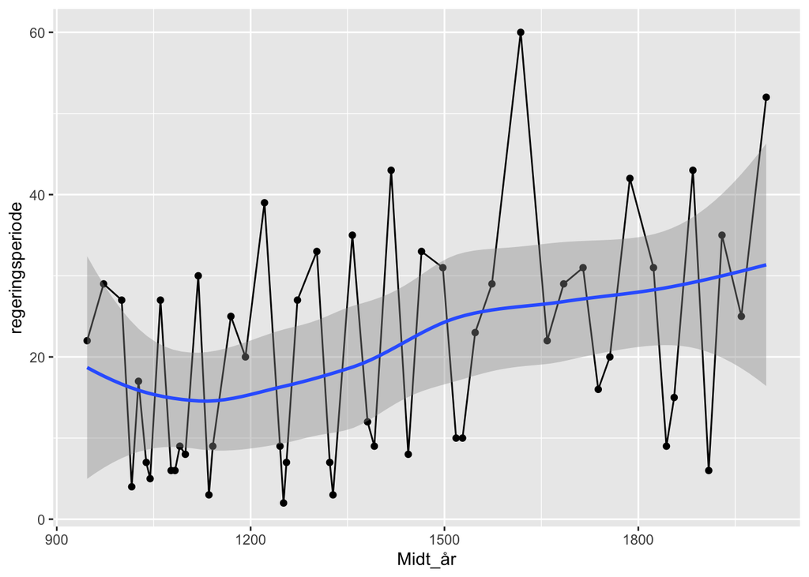

```r
konger %>%
  mutate(Midt_år = Regerinsperiode_start_aar + regeringsperiode/2) %>%
  mutate(navn_og_titel = paste(Navn, Titel)) %>%
  arrange(Midt_år) %>%
  ggplot(aes(x = Midt_år, y = regeringsperiode)) +
  geom_line() +
  geom_point()+
  geom_smooth(method = "loess")
```